# Q1_FINAL

Brian Wimmer

2022-12-05

```r
# Load libraries
library(ggplot2)
library(tidyverse)
library(psych)
library(dplyr)
library(arsenal)
library(gridExtra)
library(grid)
```

```r
# Load data

# Top 50 USA
usa <- read.csv('/Users/brianwimmer/Desktop/Georgetown/ANLY 511/Final Project/filtered_usa_top50.csv')

# Top 50 UK
uk <- read.csv('/Users/brianwimmer/Desktop/Georgetown/ANLY 511/Final Project/filtered_uk_top50.csv')
```

```r
# adding "country" column to each df; will be used for EDA purposes
usa$country <- "USA"
uk$country <- "UK"
```

```r
# combine usa and uk into one df
both <- rbind(usa, uk)
```

```r
# create df of both with just three variables (danceability, energy, and valence) of interest and country
both.interest <- both %>% select(danceability, energy, valence, country)
```

```r
# summary statistics - USA
summary(usa[c('danceability', 'energy', 'valence')])
```

```
##   danceability        energy          valence
##  Min.   :0.2340   Min.   :0.1560   Min.   :0.0374
##  1st Qu.:0.5370   1st Qu.:0.4270   1st Qu.:0.1915
##  Median :0.6465   Median :0.5250   Median :0.3565
##  Mean   :0.6252   Mean   :0.5360   Mean   :0.3931
##  3rd Qu.:0.7330   3rd Qu.:0.6428   3rd Qu.:0.5268
##  Max.   :0.9110   Max.   :0.9650   Max.   :0.9470
```

```r
# summary statistics - UK
summary(uk[c('danceability', 'energy', 'valence')])
```

```
##   danceability        energy          valence
##  Min.   :0.2470   Min.   :0.2140   Min.   :0.0374
##  1st Qu.:0.5635   1st Qu.:0.4723   1st Qu.:0.2510
##  Median :0.6395   Median :0.6240   Median :0.4330
##  Mean   :0.6404   Mean   :0.6247   Mean   :0.4954
##  3rd Qu.:0.7330   3rd Qu.:0.7900   3rd Qu.:0.6995
##  Max.   :0.9510   Max.   :0.9650   Max.   :0.9720
```

Comparison of Danceability - very minimal difference in the mean of danceability. UK is 0.64 and USA is 0.63. Expected UK to be higher as their charts often reflect more dance/edm/pop songs (“club music”). Danceability represents a combination of tempo, rhythm stability, beat strength, and regularity.  
Comparison of Energy - somewhat significant difference in the mean of energy. UK is higher at 0.62 and USA is lower at 0.54. Energy represents the intensity and activity of a song, thought this would compare easily to danceability but they are different.  
Comparison of Valence - somewhat significant difference in the mean of valence. UK is higher at 0.5 and USA is lower at 0.4. Valence compares the musical positiveness of a song, higher value means more positive.

```r
# Boxplots for variables of interest
# Boxplot for danceability variable
dance.box <- both %>%
  ggplot( aes(x = country, y = danceability, fill=country)) +
  geom_boxplot() + labs(title = "Danceability")+
    scale_fill_manual(values = c("#6699cc", "#cd5c5c")) +
  xlab("Country") + ylab("Danceability")+
  scale_y_continuous(breaks = c(0.25,0.50,0.75,1.00))+
  theme(plot.title = element_text(hjust = 0.5), plot.caption = element_text(hjust = 0.5), legend.position="none")
#dance.box

# Boxplot for energy variable
energy.box <- both %>%
  ggplot( aes(x = country, y = energy, fill=country)) +
  geom_boxplot() + labs(title = "Energy")+
    scale_fill_manual(values = c("#6699cc", "#cd5c5c")) +
  xlab("Country") + ylab("Energy")+
  theme(plot.title = element_text(hjust = 0.5), plot.caption = element_text(hjust = 0.5), legend.position="none")
#energy.box

# Boxplot for valence variable
valence.box <- both %>%
  ggplot( aes(x = country, y = valence, fill=country)) +
  geom_boxplot() + labs(title = "Valence")+
    scale_fill_manual(values = c("#6699cc", "#cd5c5c")) +
  xlab("Country") + ylab("Valence")+
  theme(plot.title = element_text(hjust = 0.5), plot.caption = element_text(hjust = 0.5), legend.position="none")
#valence.box
```

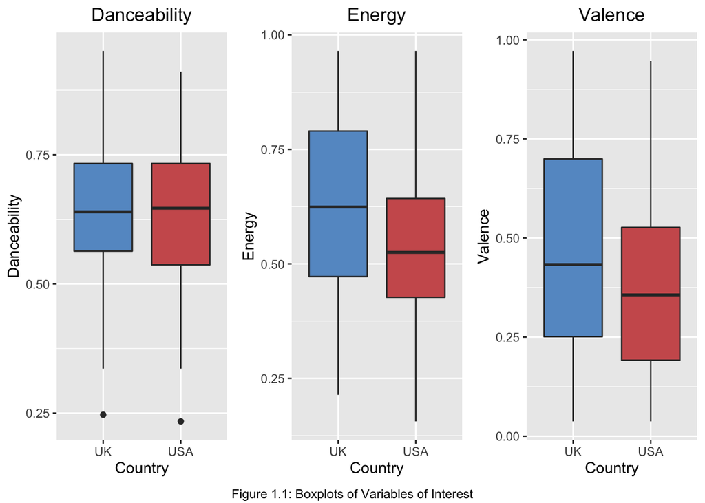

```r
# Display Boxplots for chosen variables
# Boxplots arranged in 1x3 grid
grid.arrange(dance.box, energy.box, valence.box, ncol = 3, bottom=textGrob("Figure 1.1: Boxplots of Variables of Interest", gp = gpar(fontsize = 9)))
```

In Figure 1.1, we can visualize the five-number summary of each variable using boxplots. Each boxplot is grouped by country, with blue representing the UK and red representing the USA.  
The danceability boxplot (far-left) shows that there is not much difference at all between the countries. The median danceability is slightly higher for the USA (0.65) than the UK (0.64). The interquartile range is also slightly larger for the USA than the UK.  
The energy boxplot (middle) shows that there is a significant difference between the countries. The median energy is higher for the UK (0.62) than the USA (0.53). The interquartile range is also much larger for the UK than the USA.  
The valence boxplot (far-right) shows that there is some difference between the countries. The median valence is higher for the UK (0.43) than the USA (0.36). The interquartile range is also higher for the UK than the USA.

```r
# Histogram for danceability variable, side-by-side
uk.dance.hist <- ggplot(uk, aes(x=danceability))+
  geom_histogram(binwidth=.1, color="black", fill="#6699cc")+
  labs(x="Danceability (UK) ", y = "Count")+
  scale_x_continuous(breaks=c(0.25,0.50,0.75,1.00))+
  scale_y_continuous(breaks=seq(0,20,2))+
  annotate("text", x=0.25, y=15, label= "mean = 0.64",
                  size = 3)+
  theme(plot.title = element_text(size = 10, hjust = 0.5), axis.title = element_text(size = 9))
#uk.dance.hist

usa.dance.hist <- ggplot(usa, aes(x=danceability))+
  geom_histogram(binwidth=.1, color="black", fill="#cd5c5c")+
  labs(x="Danceability (USA)", y = NULL)+
  scale_x_continuous(breaks=c(0.25,0.50,0.75,1.00))+
  scale_y_continuous(breaks=seq(0,20,2))+
  annotate("text", x=0.25, y=14, label= "mean = 0.63",
                  size = 3)+
  theme(plot.title = element_text(size = 10, hjust = 0.5), axis.title = element_text(size = 9))
#usa.dance.hist

#grid.arrange(uk.dance.hist, usa.dance.hist, ncol = 2, bottom=textGrob("Figure 1.4: Histograms of Danceability by Country", gp = gpar(fontsize = 9)))

# Histogram for energy variable, side-by-side
uk.energy.hist <- ggplot(uk, aes(x=energy))+
  geom_histogram(binwidth=.1, color="black", fill="#6699cc")+
  labs(x="Energy (UK)", y = "Count")+
  scale_x_continuous(breaks=c(0.25,0.50,0.75,1.00))+
  scale_y_continuous(breaks=seq(0,20,2))+
  annotate("text", x=0.25, y=9, label= "mean = 0.62",
                  size = 3)+
  theme(plot.title = element_text(hjust = 0.5), axis.title = element_text(size = 9))
#uk.energy.hist

usa.energy.hist <- ggplot(usa, aes(x=energy))+
  geom_histogram(binwidth=.1, color="black", fill="#cd5c5c")+
  labs(x="Energy (USA)", y = NULL)+
  scale_x_continuous(breaks=c(0.25,0.50,0.75,1.00))+
  scale_y_continuous(breaks=seq(0,20,2))+
  annotate("text", x=0.25, y=15, label= "mean = 0.54",
                  size = 3)+
  theme(plot.title = element_text(hjust = 0.5), axis.title = element_text(size = 9))
#usa.energy.hist

#grid.arrange(uk.energy.hist, usa.energy.hist, ncol = 2, bottom=textGrob("Figure 1.5: Histograms of Energy by Country", gp = gpar(fontsize = 9)))

# Histogram for valence variable, side-by-side
uk.valence.hist <- ggplot(uk, aes(x=valence))+
  geom_histogram(binwidth=.1, color="black", fill="#6699cc")+
  labs(x="Valence (UK)", y = "Count")+
  scale_x_continuous(breaks=c(0.25,0.50,0.75,1.00))+
  scale_y_continuous(breaks=seq(0,20,2))+
  annotate("text", x=0.95, y=8, label= "mean = 0.5",
                  size = 3)+
  theme(plot.title = element_text(hjust = 0.5), axis.title = element_text(size = 9))
#uk.valence.hist

usa.valence.hist <- ggplot(usa, aes(x=valence))+
  geom_histogram(binwidth=.1, color="black", fill="#cd5c5c")+
  labs(x="Valence (USA)", y = NULL)+
  scale_x_continuous(breaks=c(0.25,0.50,0.75,1.00))+
  scale_y_continuous(breaks=seq(0,20,2))+
  annotate("text", x=0.85, y=10, label= "mean = 0.4",
                  size = 3)+
  theme(plot.title = element_text(hjust = 0.5), axis.title = element_text(size = 9))
#usa.valence.hist

#grid.arrange(uk.valence.hist, usa.valence.hist, ncol = 2, bottom=textGrob("Figure 1.6: Histograms of Valence by Country", gp = gpar(fontsize = 9)))
```

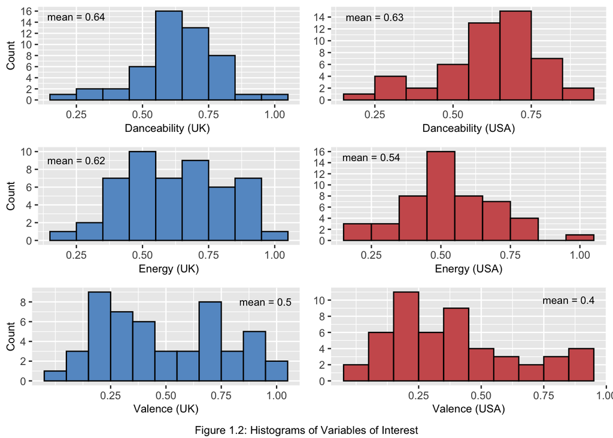

```r
grid.arrange(uk.dance.hist, usa.dance.hist, uk.energy.hist, usa.energy.hist, uk.valence.hist, usa.valence.hist,ncol = 2, bottom=textGrob("Figure 1.2: Histograms of Variables of Interest", gp = gpar(fontsize = 9)))
```

In Figure 1.2, we can visualize the distribution of each variable using histograms. Each histogram is shown by country, with blue representing the UK and red representing the USA.  
The danceability histograms (top) show that there is not much difference between the countries. The mean danceability is slightly higher for the UK (0.64) than the USA (0.63).  
The energy histograms (middle) show that there is a difference between the countries. The mean energy is higher for the UK (0.62) than the USA (0.54).  
The valence histograms (bottom) show that there is a difference between the countries. The mean valence is higher for the UK (0.5) than the USA (0.4).

Testing of Danceability:  
Let $\mu_S$ = population mean danceability of USA and $\mu_K$ = population mean danceability of UK.  
Null - $H_0: \mu_K - \mu_S = 0$ There is no difference in the average danceability between UK and USA.  
Alternative - $H_a: \mu_K - \mu_S > 0$ The average danceability is larger for UK than USA.

```r
set.seed(1999)

# Hypothesis Testing - T-test for danceability
uk.dance <- subset(both.interest, select=danceability, subset=country=="UK", drop=T)
usa.dance <- subset(both.interest, select=danceability,subset=country=="USA", drop=T)

t.test(uk.dance, usa.dance, alt="greater")
```

```
##
##  Welch Two Sample t-test
##
## data:  uk.dance and usa.dance
## t = 0.50209, df = 97.495, p-value = 0.3084
## alternative hypothesis: true difference in means is greater than 0
## 95 percent confidence interval:
##  -0.03502688         Inf
## sample estimates:
## mean of x mean of y
##   0.64036   0.62518
```

Interpretation - Since p-value is greater than 0.05, at 5% significance level, we have enough evidence to conclude that we fail to reject the null hypothesis. There is not strong evidence that the danceability of music in the top 50 in the UK is higher than music in the top 50 in the USA.

Testing of Energy:  
Let $\mu_S$ = population mean energy of USA and $\mu_K$ = population mean energy of UK.  
Null - $H_0: \mu_K - \mu_S = 0$ There is no difference in the average energy between UK and USA.  
Alternative - $H_a: \mu_K - \mu_S > 0$ The average energy is larger for UK than USA.

```r
set.seed(1999)

# Hypothesis Testing - T-test for energy
uk.energy <- subset(both.interest, select=energy, subset=country=="UK", drop=T)
usa.energy <- subset(both.interest, select=energy,subset=country=="USA", drop=T)

t.test(uk.energy, usa.energy, alt="greater")
```

```
##
##  Welch Two Sample t-test
##
## data:  uk.energy and usa.energy
## t = 2.4176, df = 97.155, p-value = 0.008744
## alternative hypothesis: true difference in means is greater than 0
## 95 percent confidence interval:
##  0.02775839        Inf
## sample estimates:
## mean of x mean of y
##   0.62468   0.53602
```

Interpretation - Since p-value is less than 0.05, at 5% significance level, we have enough evidence to conclude that we reject the null hypothesis. There is strong evidence that the energy of music in the top 50 in the UK is higher than music in the top 50 in the USA.

```r
set.seed(1999)

# bootstrap ratio of means of energy
N <- 10000
energy.diff.mean.ratio <- numeric(N)

for (i in 1:N)
{
uk.sample <- sample(uk.energy, 50, replace = TRUE)
usa.sample <- sample(usa.energy, 50, replace = TRUE)
energy.diff.mean.ratio[i] <- mean(uk.sample) / mean(usa.sample)
}

#hist(energy.diff.mean.ratio,main = "Bootstrap Distribution of Difference in Mean of Energy", col = '#6666cc', xlab = 'Difference in Mean of Energy')
#abline(v = mean(uk.energy) / mean(usa.energy), col = "black", lty = 2)


# 95 percent confidence interval
quantile(energy.diff.mean.ratio, c(0.025, 0.975))
```

```
##     2.5%    97.5%
## 1.028055 1.320461
```

The 95% bootstrap percentile confidence interval for the ratio of means (UK energy / USA energy) is (1.03, 1.32). Thus, we are 95% confident that the energy of top 50 UK songs are, on average, between 1.03 and 1.32 times greater than top 50 USA songs.

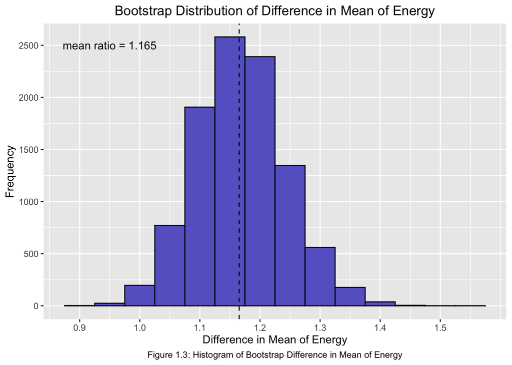

```r
# create copy of energy.diff.mean.ratio into df
energy.diff.mean.ratio.df <- as.data.frame(energy.diff.mean.ratio)

# Histogram for bootstrap ratio of means of energy
boot.energy.hist <- ggplot(energy.diff.mean.ratio.df, aes(x=energy.diff.mean.ratio))+
  geom_histogram(binwidth=0.05, color="black", fill="#6666cc")+
  labs(title="Bootstrap Distribution of Difference in Mean of Energy", x = "Difference in Mean of Energy", y = "Frequency", caption = "Figure 1.3: Histogram of Bootstrap Difference in Mean of Energy")+
  annotate("text", x=.95, y=2500, label= "mean ratio = 1.165")+
  scale_x_continuous(breaks=c(0.9, 1.0, 1.1, 1.2, 1.3, 1.4, 1.5))+
  scale_y_continuous(breaks=seq(0,2500,500))+
  theme(plot.title = element_text(hjust = 0.5), plot.caption = element_text(hjust = 0.5))+
  geom_vline(xintercept = mean(mean(uk.energy) / mean(usa.energy)), col = "black", linetype="dashed")

boot.energy.hist
```

In Figure 1.3, we can see the distribution of the difference in mean energy between the UK and the USA. The difference in the ratio of mean of energy is 1.165. On average, UK top 50 songs are 1.165 times greater than that of the USA top 50 songs.

Testing of Valence:  
Let $\mu_S$ = population mean valence of USA and $\mu_K$ = population mean valence of UK.  
Null - $H_0: \mu_K - \mu_S = 0$ There is no difference in the average valence between UK and USA.  
Alternative - $H_a: \mu_K - \mu_S > 0$ The average valence is larger for UK than USA.

```r
set.seed(1999)

# Hypothesis Testing - T-test for valence
uk.valence <- subset(both.interest, select=valence, subset=country=="UK", drop=T)
usa.valence <- subset(both.interest, select=valence,subset=country=="USA", drop=T)

t.test(uk.valence, usa.valence, alt="greater")
```

```
##
##  Welch Two Sample t-test
##
## data:  uk.valence and usa.valence
## t = 1.949, df = 97.448, p-value = 0.02709
## alternative hypothesis: true difference in means is greater than 0
## 95 percent confidence interval:
##  0.01513129        Inf
## sample estimates:
## mean of x mean of y
##  0.495358  0.393088
```

Interpretation - Since p-value is less than 0.05, at 5% significance level, we have enough evidence to conclude that we reject the null hypothesis. Therefore there is strong evidence that the valence of music in the top 50 in the UK is higher than music in the top 50 in the USA.

```r
set.seed(1999)

# bootstrap ratio of means of valence
N <- 10000
valence.diff.mean.ratio <- numeric(N)

for (i in 1:N)
{
uk.sample <- sample(uk.valence, 50, replace = TRUE)
usa.sample <- sample(usa.valence, 50, replace = TRUE)
valence.diff.mean.ratio[i] <- mean(uk.sample) / mean(usa.sample)
}

#hist(valence.diff.mean.ratio,main = "Bootstrap Distribution of Difference in Mean of Valence", col = '#6666cc', xlab = 'Difference in Mean of Valence')
#abline(v = mean(uk.valence) / mean(usa.valence), col = "black", lty = 2)


# 95 percent confidence interval
quantile(valence.diff.mean.ratio, c(0.025, 0.975))
```

```
##     2.5%    97.5%
## 1.000473 1.588290
```

The 95% bootstrap percentile confidence interval for the ratio of means (UK valence / USA valence) is (1, 1.59). Thus, we are 95% confident that the valence of top 50 UK songs are, on average, between 1 and 1.59 times greater than top 50 USA songs.

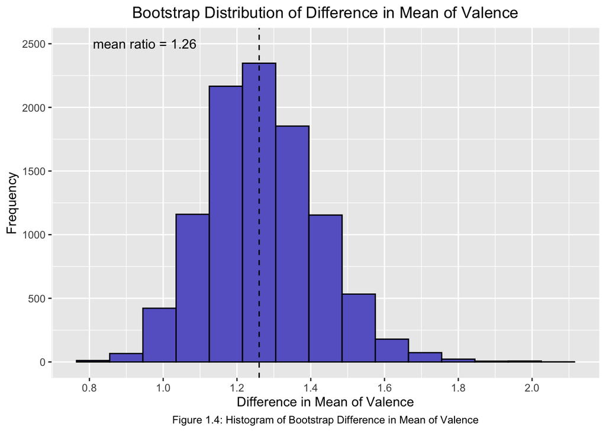

```r
# create copy of valence.diff.mean.ratio into df
valence.diff.mean.ratio.df <- as.data.frame(valence.diff.mean.ratio)

# Histogram for bootstrap ratio of means of energy
boot.valence.hist <- ggplot(valence.diff.mean.ratio.df, aes(x=valence.diff.mean.ratio))+
  geom_histogram(binwidth=0.09, color="black", fill="#6666cc")+
  labs(title="Bootstrap Distribution of Difference in Mean of Valence", x = "Difference in Mean of Valence", y = "Frequency", caption = "Figure 1.4: Histogram of Bootstrap Difference in Mean of Valence")+
  annotate("text", x=.95, y=2500, label= "mean ratio = 1.26")+
  scale_x_continuous(breaks=c(0.8, 1.0, 1.2, 1.4, 1.6, 1.8, 2.0))+
  scale_y_continuous(breaks=seq(0,2500,500))+
  theme(plot.title = element_text(hjust = 0.5), plot.caption = element_text(hjust = 0.5))+
  geom_vline(xintercept = mean(mean(uk.valence) / mean(usa.valence)), col = "black", linetype="dashed")

boot.valence.hist
```

In Figure 1.4, we can see the distribution of the difference in mean valence between the UK and the USA. The difference in the ratio of mean of valence is 1.26. On average, UK top 50 songs are 1.26 times greater than that of the USA top 50 songs.

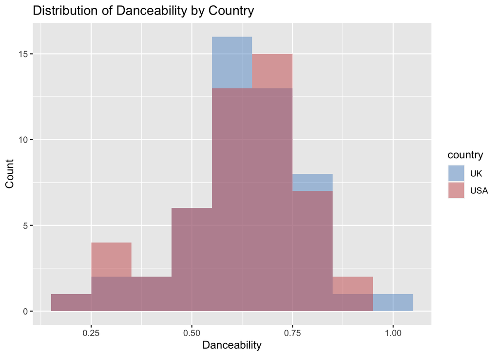

```r
# Appendix - Histograms (overlay) for each variable of interest
# Histogram for danceability variable, overlaid
dance.hist.over <- ggplot(both, aes(x = danceability, fill = country)) +
  geom_histogram(position = "identity", alpha = 0.5, binwidth = .1)+
    scale_fill_manual(values = c("#6699cc", "#cd5c5c"))+
  labs(title="Distribution of Danceability by Country",x="Danceability", y = "Count")
dance.hist.over
```

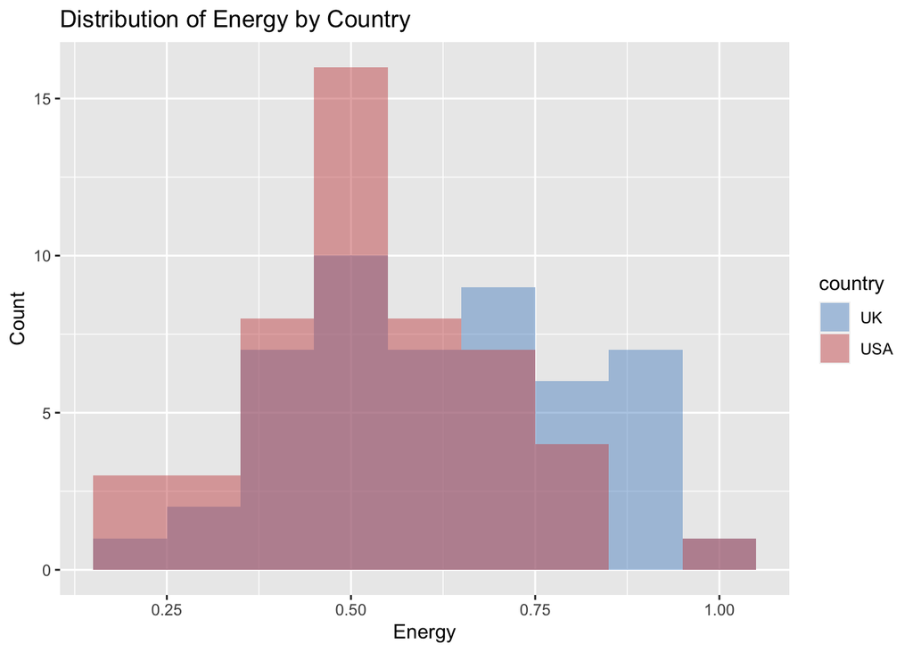

```r
# Histogram for energy variable, overlaid
dance.energy.over <- ggplot(both, aes(x = energy, fill = country)) +
  geom_histogram(position = "identity", alpha = 0.5, binwidth = .1)+
    scale_fill_manual(values = c("#6699cc", "#cd5c5c"))+
  labs(title="Distribution of Energy by Country",x="Energy", y = "Count")
dance.energy.over
```

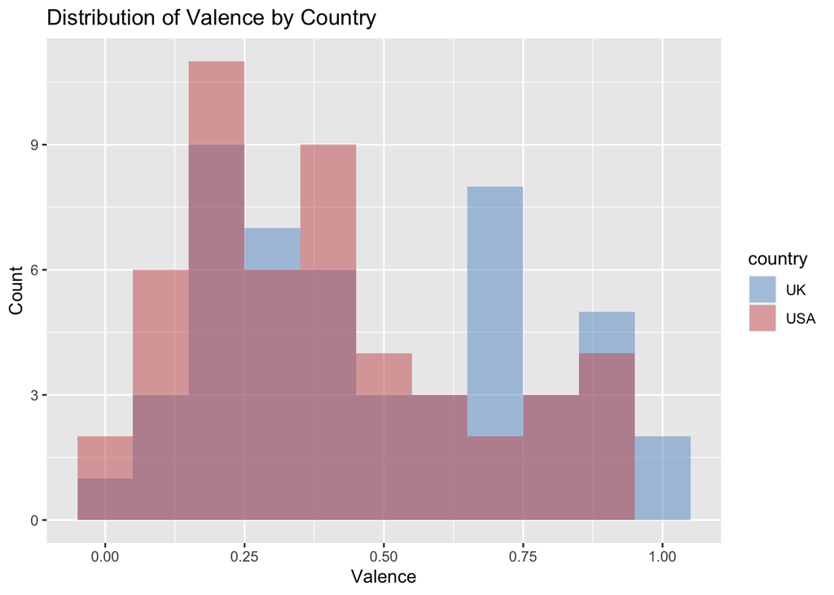

```r
# Histogram for valence variable, overlaid
dance.valence.over <- ggplot(both, aes(x = valence, fill = country)) +
  geom_histogram(position = "identity", alpha = 0.5, binwidth = .1)+
    scale_fill_manual(values = c("#6699cc", "#cd5c5c"))+
  labs(title="Distribution of Valence by Country",x="Valence", y = "Count")
dance.valence.over
```

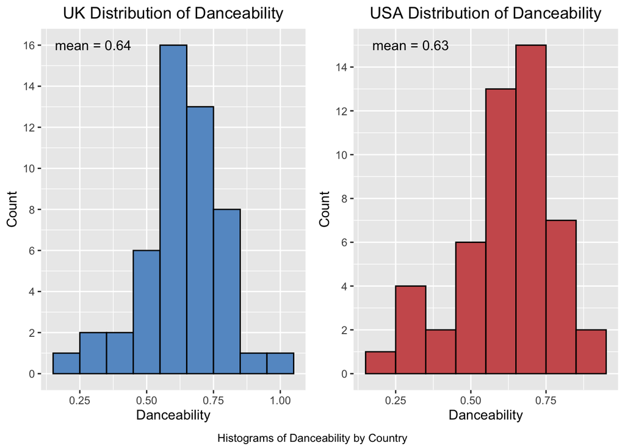

```r
# Histogram for danceability variable, side-by-side
uk.dance.hist <- ggplot(uk, aes(x=danceability))+
  geom_histogram(binwidth=.1, color="black", fill="#6699cc")+
  labs(title="UK Distribution of Danceability",x="Danceability", y = "Count")+
  scale_x_continuous(breaks=c(0.25,0.50,0.75,1.00))+
  scale_y_continuous(breaks=seq(0,20,2))+
  annotate("text", x=0.3, y=16, label= "mean = 0.64")+
  theme(plot.title = element_text(hjust = 0.5))
#uk.dance.hist

usa.dance.hist <- ggplot(usa, aes(x=danceability))+
  geom_histogram(binwidth=.1, color="black", fill="#cd5c5c")+
  labs(title="USA Distribution of Danceability",x="Danceability", y = "Count")+
  scale_x_continuous(breaks=c(0.25,0.50,0.75,1.00))+
  scale_y_continuous(breaks=seq(0,20,2))+
  annotate("text", x=0.3, y=15, label= "mean = 0.63")+
  theme(plot.title = element_text(hjust = 0.5))
#usa.dance.hist

grid.arrange(uk.dance.hist, usa.dance.hist, ncol = 2, bottom=textGrob("Histograms of Danceability by Country", gp = gpar(fontsize = 9)))
```

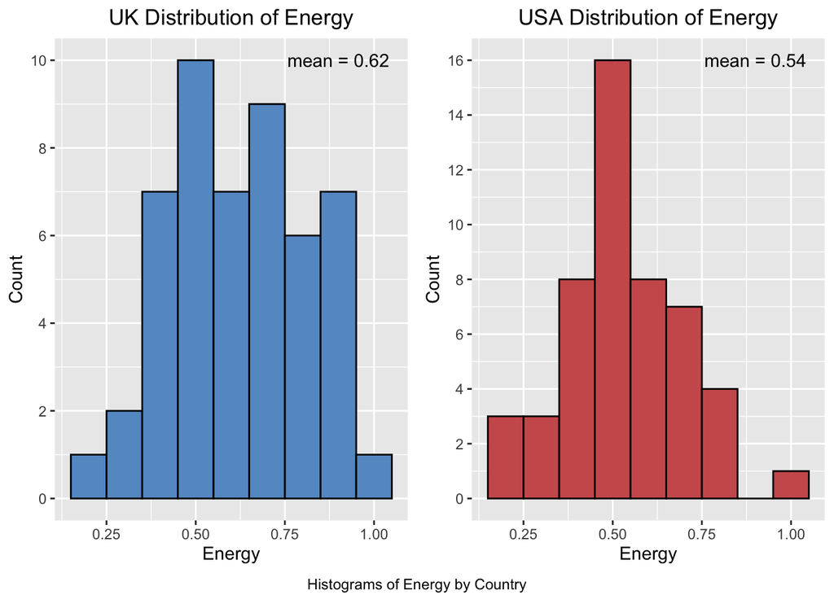

```r
# Histogram for energy variable, side-by-side
uk.energy.hist <- ggplot(uk, aes(x=energy))+
  geom_histogram(binwidth=.1, color="black", fill="#6699cc")+
  labs(title="UK Distribution of Energy",x="Energy", y = "Count")+
  scale_x_continuous(breaks=c(0.25,0.50,0.75,1.00))+
  scale_y_continuous(breaks=seq(0,20,2))+
  annotate("text", x=0.9, y=10, label= "mean = 0.62")+
  theme(plot.title = element_text(hjust = 0.5))
#uk.energy.hist

usa.energy.hist <- ggplot(usa, aes(x=energy))+
  geom_histogram(binwidth=.1, color="black", fill="#cd5c5c")+
  labs(title="USA Distribution of Energy",x="Energy", y = "Count")+
  scale_x_continuous(breaks=c(0.25,0.50,0.75,1.00))+
  scale_y_continuous(breaks=seq(0,20,2))+
  annotate("text", x=0.9, y=16, label= "mean = 0.54")+
  theme(plot.title = element_text(hjust = 0.5))
#usa.energy.hist

grid.arrange(uk.energy.hist, usa.energy.hist, ncol = 2, bottom=textGrob("Histograms of Energy by Country", gp = gpar(fontsize = 9)))
```

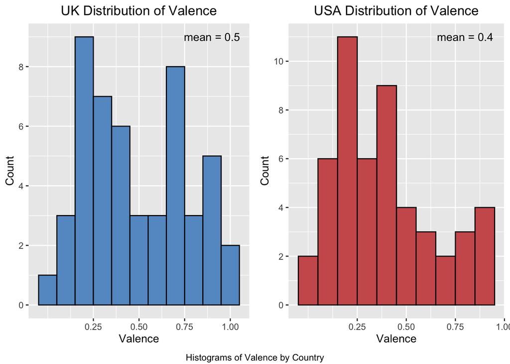

```r
# Histogram for valence variable, side-by-side
uk.valence.hist <- ggplot(uk, aes(x=valence))+
  geom_histogram(binwidth=.1, color="black", fill="#6699cc")+
  labs(title="UK Distribution of Valence",x="Valence", y = "Count")+
  scale_x_continuous(breaks=c(0.25,0.50,0.75,1.00))+
  scale_y_continuous(breaks=seq(0,20,2))+
  annotate("text", x=0.9, y=9, label= "mean = 0.5")+
  theme(plot.title = element_text(hjust = 0.5))
#uk.valence.hist

usa.valence.hist <- ggplot(usa, aes(x=valence))+
  geom_histogram(binwidth=.1, color="black", fill="#cd5c5c")+
  labs(title="USA Distribution of Valence",x="Valence", y = "Count")+
  scale_x_continuous(breaks=c(0.25,0.50,0.75,1.00))+
  scale_y_continuous(breaks=seq(0,20,2))+
  annotate("text", x=0.8, y=11, label= "mean = 0.4")+
  theme(plot.title = element_text(hjust = 0.5))
#usa.valence.hist

grid.arrange(uk.valence.hist, usa.valence.hist, ncol = 2, bottom=textGrob("Histograms of Valence by Country", gp = gpar(fontsize = 9)))
```